# Scotts

Zihao

August 29, 2017

## Training data

We have scotts sales data and related variables from 2013-10-06 to 2017-06-25. I separate the data into Training data of (2013-10-06 – 2016-06-25) and test data (2016-06-25 – 2017-06-25). In this example, I predict the “Lawn.Fertilizer.Sales.Units” using weather, marketing activity and DMA information. The dependent variable sum over DMA looks like below:

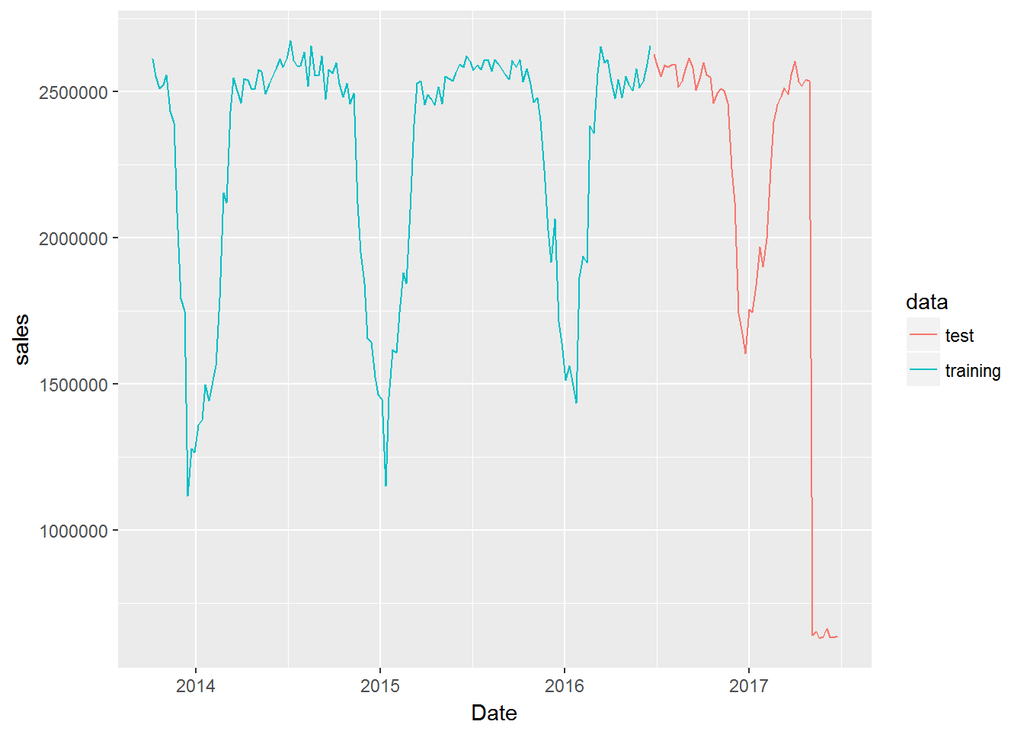

## Models

The most popular prediction machine learning are tree-based model including Random Forest and XGboost Tree because of high prediction accuracy. The simple version of tree-model looks like below.

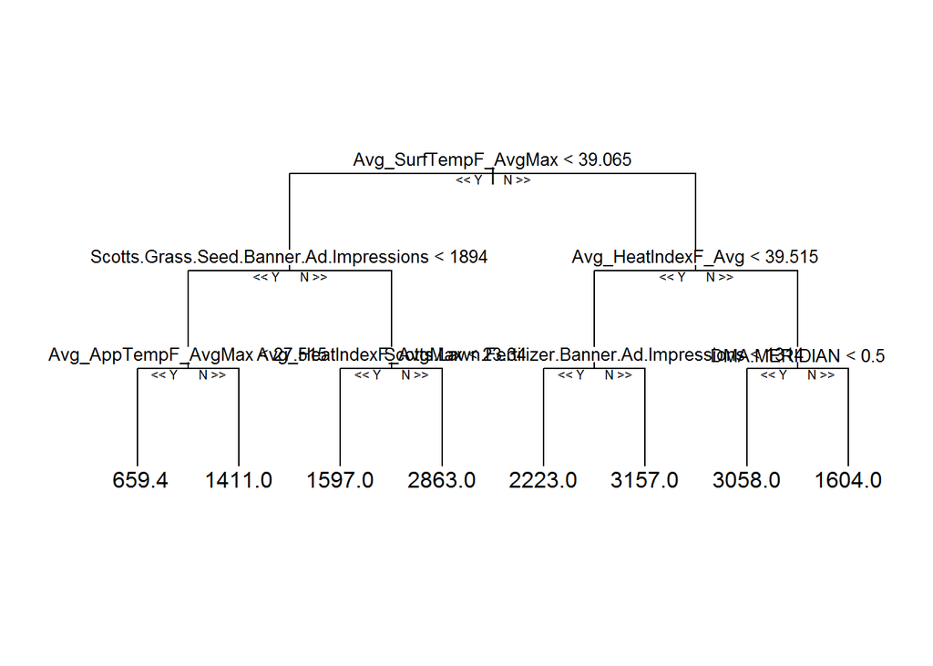

The following figure visualize the relation between Sales and Average Temperature. We can see temperature will boost sales in range 20 to 40 while sales wouldn’t change with temperature when temperature is over 40. If we force a linear model on this dataset, we would get bad prediction.

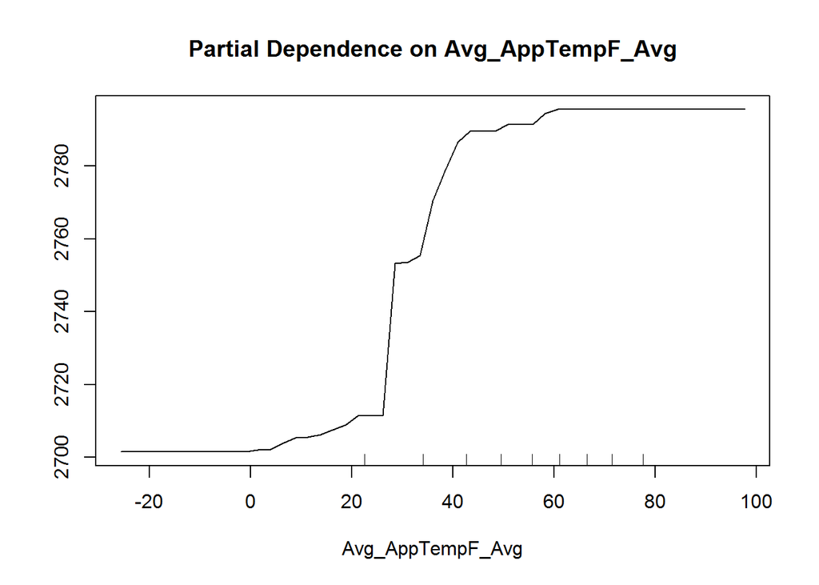

## Prediction

Overall, The aggregated forecasting looks fine. The forecasting model capture seasonal trend well. However, the forecasting model cannot explain the sharpe drop in May of 2017 because this pattern never happened in training data.

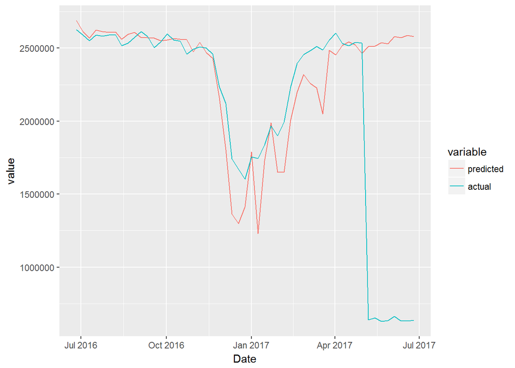

Breaking down the prediction to Retalier level, the forecasting results is pretty well in ACE where the trend is similar with training data.

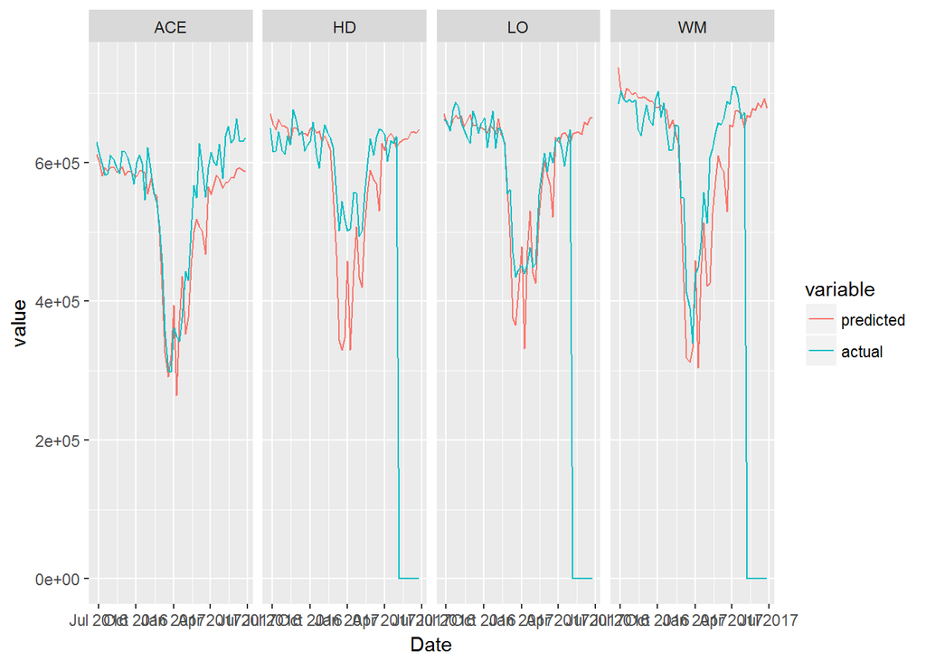